# Attention Is All You Need — Step-by-Step Visual Guide

**Paper:** [Attention Is All You Need, Vaswani et al. 2017](https://arxiv.org/abs/1706.03762)

**Goal:** Take one sentence and walk every word through the full transformer encoder step by step. See every matrix. Plot every transformation. Understand *why* each piece exists.

By the end you will know:

- What "attention" actually computes — as a matrix operation you can trace by hand
- Why random rotation / scaling matters (sqrt d_k)
- What multi-head attention adds over single-head
- How positional encoding solves "bag of words"
- Where this shows up in GPT, BERT, ViT, Whisper, and your own projects

## 0 · The Problem: Sequential Processing Breaks at Scale

Before transformers, sequence models were **RNNs** (LSTM, GRU). They read one token at a time and pass a hidden state forward.

```
"The" → h1 → "cat" → h2 → "sat" → h3 → "on" → h4 → "the" → h5 → "mat" → h6
```

**Problems:**

1. **Not parallelisable** — step n needs step n-1. GPUs sit idle.
2. **Long-range forgetting** — by the time we process "mat", information about "The" is diluted through 5 hidden states.
3. **Fixed bottleneck** — all context must pass through one vector h.

**The transformer's answer:** throw away the sequential assumption entirely. Let every token attend to every other token *simultaneously*.

```
"The" ─┐    ┌─ "The"
"cat" ─┼────┼─ "cat"
"sat" ─┼────┼─ "sat"   ← every token sees every other token in one step
"on"  ─┼────┼─ "on"
"the" ─┼────┼─ "the"
"mat" ─┘    └─ "mat"
```

```python
import numpy as np
import matplotlib.pyplot as plt
import matplotlib.gridspec as gridspec
from attention import (
    softmax, layer_norm,
    scaled_dot_product_attention,
    MultiHeadAttention,
    positional_encoding,
    FeedForward,
    EncoderBlock,
)

plt.rcParams.update({
    "figure.facecolor": "#0f1117", "axes.facecolor": "#1a1d27",
    "axes.edgecolor": "#2a2d3e", "axes.labelcolor": "#e2e8f0",
    "text.color": "#e2e8f0", "xtick.color": "#64748b", "ytick.color": "#64748b",
    "grid.color": "#2a2d3e", "grid.linewidth": 0.6, "axes.grid": False,
    "figure.dpi": 110, "font.size": 11,
})
C0, C1, C2, C3, C4 = "#6366f1", "#22c55e", "#f59e0b", "#ef4444", "#8b5cf6"

np.random.seed(42)
print("Ready.")
```

```
Ready.
```

## 1 · Our Sentence

We will use this sentence through the entire notebook:

> **"The cat sat on the mat"**

6 tokens. Small enough to visualise every matrix. We use `d_model = 8` (embedding dimension) so we can see every number.

```python
TOKENS  = ["The", "cat", "sat", "on", "the", "mat"]
SEQ_LEN = len(TOKENS)
D_MODEL = 8
N_HEADS = 2
D_FF    = 16
D_K     = D_MODEL // N_HEADS  # 4 per head

print(f"Tokens:   {TOKENS}")
print(f"Sequence length: {SEQ_LEN}")
print(f"d_model = {D_MODEL}  |  n_heads = {N_HEADS}  |  d_k = {D_K}")
print(f"Total input matrix shape: {SEQ_LEN} x {D_MODEL}")
```

```
Tokens:   ['The', 'cat', 'sat', 'on', 'the', 'mat']
Sequence length: 6
d_model = 8  |  n_heads = 2  |  d_k = 4
Total input matrix shape: 6 x 8
```

## 2 · Word Embeddings — Tokens Become Vectors

Each token is first looked up in an **embedding table** (a learned matrix). Here we use random embeddings fixed by seed — in a real model these are learned.

Every word becomes a `d_model`-dimensional vector. Similar words end up with similar vectors after training.

```python
rng = np.random.default_rng(42)
# embedding table: one vector per token (in practice: vocab_size x d_model)
E = rng.standard_normal((SEQ_LEN, D_MODEL)) * 0.5
# Normalise to unit norm (common initialisation)
E = E / np.linalg.norm(E, axis=1, keepdims=True)

print("Embedding matrix E  (shape: seq_len x d_model):")
print(E.round(3))
```

```
Embedding matrix E  (shape: seq_len x d_model):
[[ 0.106 -0.362  0.261  0.328 -0.68  -0.454  0.045 -0.11 ]
 [-0.008 -0.41   0.422  0.373  0.032  0.541  0.224 -0.413]
 [ 0.188 -0.489  0.448 -0.025 -0.094 -0.347  0.623 -0.079]
 [-0.177 -0.146  0.22   0.151  0.171  0.178  0.887 -0.168]
 [-0.244 -0.388  0.294  0.538 -0.054 -0.401 -0.393  0.31 ]
 [ 0.499  0.365 -0.447  0.156  0.078  0.147  0.586  0.15 ]]
```

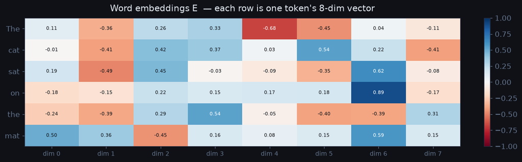

```
Each row = one word's representation. Columns = learned features (abstract).
```

```python
fig, ax = plt.subplots(figsize=(11, 3.5))
im = ax.imshow(E, aspect="auto", cmap="RdBu", vmin=-1, vmax=1)
ax.set_xticks(range(D_MODEL))
ax.set_xticklabels([f"dim {i}" for i in range(D_MODEL)], fontsize=9)
ax.set_yticks(range(SEQ_LEN))
ax.set_yticklabels(TOKENS, fontsize=11)
ax.set_title('Word embeddings E  — each row is one token\'s 8-dim vector', pad=10)
plt.colorbar(im, ax=ax, fraction=0.02)
for i in range(SEQ_LEN):
    for j in range(D_MODEL):
        ax.text(j, i, f"{E[i,j]:.2f}", ha="center", va="center", fontsize=7,
                color="white" if abs(E[i,j]) > 0.5 else "#0f1117")
plt.tight_layout(); plt.show()
print("Each row = one word's representation. Columns = learned features (abstract).")
```

## 3 · Positional Encoding — Telling the Model Where Words Are

Without position information, the transformer treats tokens as a **bag of words**. "The cat sat on the mat" and "the mat sat on the cat" would look identical.

**Solution:** add a unique positional signal to each embedding.

$$PE_{(pos,\, 2i)} = \sin\!\left(\frac{pos}{10000^{2i/d}}\right)$$ $$PE_{(pos,\, 2i+1)} = \cos\!\left(\frac{pos}{10000^{2i/d}}\right)$$

**Why sine/cosine?**

- Deterministic (no extra parameters to learn)
- Every position gets a unique pattern
- Nearby positions have similar patterns (smooth continuity)
- The model can extrapolate to sequence lengths not seen during training

```python
PE = positional_encoding(SEQ_LEN, D_MODEL)

print("Positional encoding PE  (shape: seq_len x d_model):")
print(PE.round(3))
```

```
Positional encoding PE  (shape: seq_len x d_model):
[[ 0.     1.     0.     1.     0.     1.     0.     1.   ]
 [ 0.841  0.54   0.1    0.995  0.01   1.     0.001  1.   ]
 [ 0.909 -0.416  0.199  0.98   0.02   1.     0.002  1.   ]
 [ 0.141 -0.99   0.296  0.955  0.03   1.     0.003  1.   ]
 [-0.757 -0.654  0.389  0.921  0.04   0.999  0.004  1.   ]
 [-0.959  0.284  0.479  0.878  0.05   0.999  0.005  1.   ]]
```

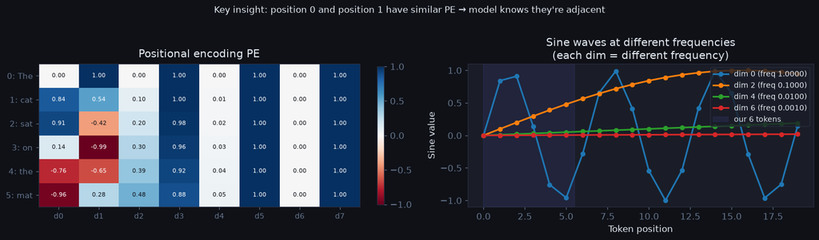

```python
fig, axes = plt.subplots(1, 2, figsize=(14, 4))

# Left: heatmap of PE
ax = axes[0]
im = ax.imshow(PE, aspect="auto", cmap="RdBu", vmin=-1, vmax=1)
ax.set_xticks(range(D_MODEL))
ax.set_xticklabels([f"d{i}" for i in range(D_MODEL)], fontsize=9)
ax.set_yticks(range(SEQ_LEN))
ax.set_yticklabels([f"{i}: {t}" for i, t in enumerate(TOKENS)], fontsize=10)
ax.set_title("Positional encoding PE", pad=8)
plt.colorbar(im, ax=ax, fraction=0.02)
for i in range(SEQ_LEN):
    for j in range(D_MODEL):
        ax.text(j, i, f"{PE[i,j]:.2f}", ha="center", va="center",
                fontsize=7, color="white" if abs(PE[i,j]) > 0.5 else "#0f1117")

# Right: show the sine waves
ax = axes[1]
dims_to_show = [0, 2, 4, 6]   # even dims (sine)
pos_range = np.arange(20)      # show first 20 positions
for d in dims_to_show:
    pe_ext = positional_encoding(20, D_MODEL)
    ax.plot(pos_range, pe_ext[:, d], marker="o", ms=5, lw=2,
            label=f"dim {d} (freq {1/10000**(d/D_MODEL):.4f})")
ax.axvspan(0, SEQ_LEN - 0.5, alpha=0.1, color=C0, label="our 6 tokens")
ax.set_xlabel("Token position"); ax.set_ylabel("Sine value")
ax.set_title("Sine waves at different frequencies\n(each dim = different frequency)")
ax.legend(fontsize=9, loc="upper right",
          facecolor="#1a1d27", edgecolor="#2a2d3e", labelcolor="#e2e8f0")

plt.suptitle("Key insight: position 0 and position 1 have similar PE → model knows they're adjacent",
             y=1.01, fontsize=11)
plt.tight_layout(); plt.show()
```

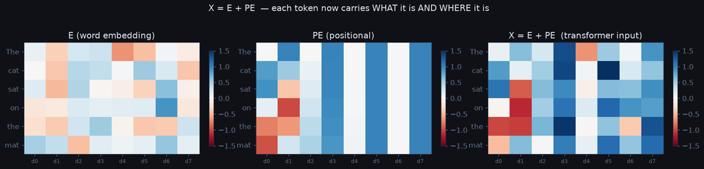

```python
# Add positional encoding to embeddings
X = E + PE   # (seq_len, d_model) — this is the actual input to the transformer

fig, axes = plt.subplots(1, 3, figsize=(15, 3.5))
for ax, mat, title in zip(axes,
    [E,  PE,  X],
    ["E (word embedding)", "PE (positional)", "X = E + PE  (transformer input)"]):
    im = ax.imshow(mat, aspect="auto", cmap="RdBu", vmin=-1.5, vmax=1.5)
    ax.set_xticks(range(D_MODEL)); ax.set_xticklabels([f"d{j}" for j in range(D_MODEL)], fontsize=8)
    ax.set_yticks(range(SEQ_LEN)); ax.set_yticklabels(TOKENS)
    ax.set_title(title, pad=6)
    plt.colorbar(im, ax=ax, fraction=0.025)
plt.suptitle("X = E + PE  — each token now carries WHAT it is AND WHERE it is", y=1.02)
plt.tight_layout(); plt.show()
```

## 4 · Query, Key, Value — The Three Projections

This is the conceptual heart of attention. Each token produces **three** vectors:

| Vector | Analogy | Role |
| --- | --- | --- |
| **Q** (Query) | "What am I looking for?" | Token asking a question |
| **K** (Key) | "What do I contain?" | Token advertising its content |
| **V** (Value) | "What I actually give you" | Token's actual contribution |

Each is a learned linear projection of X:

$$Q = X W_Q, \quad K = X W_K, \quad V = X W_V$$

$W_Q, W_K, W_V \in \mathbb{R}^{d_{model} \times d_{model}}$ are learned during training.

**Intuition:** for the word "sat", its Query might ask "who/what did the sitting?" Its Key might say "I'm a verb". When "cat"'s Query matches "sat"'s Key, attention flows.

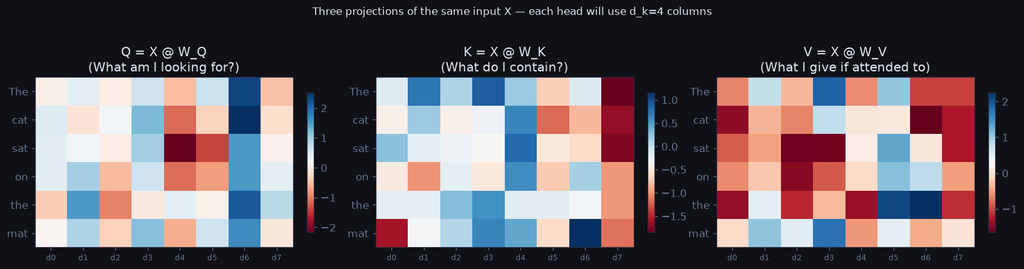

```python
mha = MultiHeadAttention(D_MODEL, N_HEADS, seed=42)

# Raw projections (before splitting into heads)
Q_full = X @ mha.W_Q   # (6, 8)
K_full = X @ mha.W_K   # (6, 8)
V_full = X @ mha.W_V   # (6, 8)

fig, axes = plt.subplots(1, 3, figsize=(15, 3.8))
for ax, mat, label in zip(axes,
    [Q_full, K_full, V_full],
    ["Q = X @ W_Q\n(What am I looking for?)",
     "K = X @ W_K\n(What do I contain?)",
     "V = X @ W_V\n(What I give if attended to)"]):
    im = ax.imshow(mat, aspect="auto", cmap="RdBu")
    ax.set_xticks(range(D_MODEL)); ax.set_xticklabels([f"d{j}" for j in range(D_MODEL)], fontsize=8)
    ax.set_yticks(range(SEQ_LEN)); ax.set_yticklabels(TOKENS)
    ax.set_title(label, pad=6)
    plt.colorbar(im, ax=ax, fraction=0.025)
plt.suptitle("Three projections of the same input X — each head will use d_k=4 columns",
             y=1.02, fontsize=11)
plt.tight_layout(); plt.show()
```

## 5 · Attention Scores — Q · Kᵀ

Now we compute how much every token should attend to every other token.

$$\text{scores} = Q \cdot K^\top \in \mathbb{R}^{seq \times seq}$$

`scores[i, j]` = dot product of token i's Query with token j's Key.

- **High score:** token i's question matches token j's advertisement → attend more
- **Low score:** token i is not interested in token j → attend less

We use head 0 (one of our 2 heads) with its `d_k = 4` slice of Q and K.

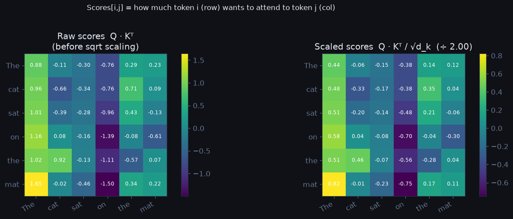

```
Score range BEFORE scaling: [-1.497, 1.645]
Score range AFTER  scaling: [-0.748, 0.823]
```

```python
# Head 0 — use first d_k columns of Q and K
Q0 = Q_full[:, :D_K]   # (6, 4)
K0 = K_full[:, :D_K]   # (6, 4)
V0 = V_full[:, :D_K]   # (6, 4)

# Raw attention scores (before scaling)
scores_raw = Q0 @ K0.T   # (6, 6)

fig, axes = plt.subplots(1, 2, figsize=(13, 4.5))

ax = axes[0]
im = ax.imshow(scores_raw, cmap="viridis")
ax.set_xticks(range(SEQ_LEN)); ax.set_xticklabels(TOKENS, rotation=30, ha="right")
ax.set_yticks(range(SEQ_LEN)); ax.set_yticklabels(TOKENS)
ax.set_title("Raw scores  Q · Kᵀ\n(before sqrt scaling)", pad=6)
plt.colorbar(im, ax=ax, fraction=0.04)
for i in range(SEQ_LEN):
    for j in range(SEQ_LEN):
        ax.text(j, i, f"{scores_raw[i,j]:.2f}", ha="center", va="center", fontsize=8,
                color="white")

# Scaled
scores_scaled = scores_raw / np.sqrt(D_K)
ax = axes[1]
im = ax.imshow(scores_scaled, cmap="viridis")
ax.set_xticks(range(SEQ_LEN)); ax.set_xticklabels(TOKENS, rotation=30, ha="right")
ax.set_yticks(range(SEQ_LEN)); ax.set_yticklabels(TOKENS)
ax.set_title(f"Scaled scores  Q · Kᵀ / √d_k  (÷ {np.sqrt(D_K):.2f})", pad=6)
plt.colorbar(im, ax=ax, fraction=0.04)
for i in range(SEQ_LEN):
    for j in range(SEQ_LEN):
        ax.text(j, i, f"{scores_scaled[i,j]:.2f}", ha="center", va="center", fontsize=8,
                color="white")

plt.suptitle("Scores[i,j] = how much token i (row) wants to attend to token j (col)",
             y=1.02, fontsize=11)
plt.tight_layout(); plt.show()

print(f"Score range BEFORE scaling: [{scores_raw.min():.3f}, {scores_raw.max():.3f}]")
print(f"Score range AFTER  scaling: [{scores_scaled.min():.3f}, {scores_scaled.max():.3f}]")
```

## 6 · Why Divide by √d_k? — The Softmax Saturation Problem

**The problem:** dot products grow with dimension. If Q and K have random entries with variance 1, then $Q \cdot K$ has variance $d_k$. Large values → softmax returns near-one-hot distribution → gradients vanish.

**Demonstration below:** as dot product magnitude grows, softmax "sharpens" until one weight → 1 and all others → 0. The model stops learning.

Dividing by $\sqrt{d_k}$ keeps variance at 1 regardless of dimension.

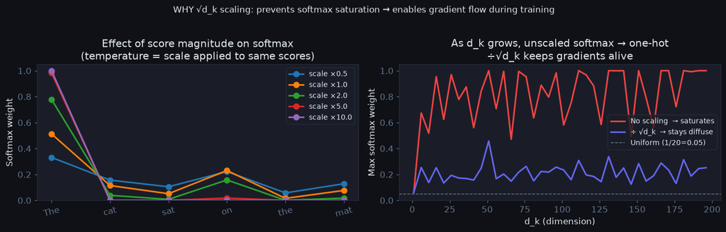

```python
fig, axes = plt.subplots(1, 2, figsize=(13, 4))

# Left: softmax shape at different temperatures
temps = [0.5, 1.0, 2.0, 5.0, 10.0]
x_vals = np.array([2.0, 0.5, -0.3, 1.2, -1.5, 0.1])   # 6 scores

ax = axes[0]
for t in temps:
    sm = softmax(x_vals * t)
    ax.plot(range(len(x_vals)), sm, "o-", lw=2, ms=7, label=f"scale ×{t}")
ax.set_xticks(range(len(TOKENS))); ax.set_xticklabels(TOKENS, rotation=15)
ax.set_ylabel("Softmax weight"); ax.set_ylim(0, 1.05)
ax.set_title("Effect of score magnitude on softmax\n(temperature = scale applied to same scores)")
ax.legend(fontsize=9, facecolor="#1a1d27", edgecolor="#2a2d3e", labelcolor="#e2e8f0")

# Right: max softmax weight as dimension grows (no scaling vs with scaling)
dims = np.arange(1, 200, 5)
max_weights_unscaled = []
max_weights_scaled   = []
rng2 = np.random.default_rng(0)
for d in dims:
    q = rng2.standard_normal(d)
    k = rng2.standard_normal((20, d))
    scores_u = q @ k.T                        # unscaled
    scores_s = q @ k.T / np.sqrt(d)           # scaled
    max_weights_unscaled.append(softmax(scores_u).max())
    max_weights_scaled.append(softmax(scores_s).max())

ax = axes[1]
ax.plot(dims, max_weights_unscaled, color=C3, lw=2, label="No scaling  → saturates")
ax.plot(dims, max_weights_scaled,   color=C0, lw=2, label="÷ √d_k  → stays diffuse")
ax.axhline(1/20, color="#64748b", ls="--", lw=1, label="Uniform (1/20=0.05)")
ax.set_xlabel("d_k (dimension)"); ax.set_ylabel("Max softmax weight")
ax.set_title("As d_k grows, unscaled softmax → one-hot\n÷√d_k keeps gradients alive")
ax.legend(fontsize=9, facecolor="#1a1d27", edgecolor="#2a2d3e", labelcolor="#e2e8f0")
ax.set_ylim(0, 1.05)

plt.suptitle("WHY √d_k scaling: prevents softmax saturation → enables gradient flow during training",
             y=1.02, fontsize=11)
plt.tight_layout(); plt.show()
```

## 7 · Softmax → Attention Weights

Apply softmax row-wise so each token's attention sums to 1.

$$A = \text{softmax}\!\left(\frac{Q K^\top}{\sqrt{d_k}}\right) \in [0,1]^{seq \times seq}$$

Row $i$ tells us: **when outputting token $i$, how much do I attend to each position?**

- $A_{ij} = 0.9$ → token $i$ mostly uses information from token $j$
- Rows sum to 1.0 (probability distribution over sequence positions)

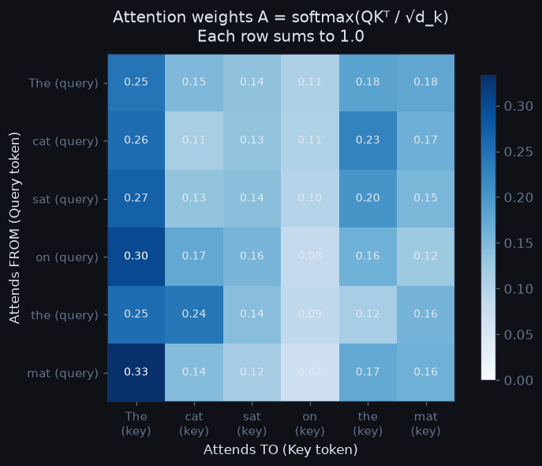

```
Row sums: [1. 1. 1. 1. 1. 1.] ← all 1.0 ✓
```

```python
weights_h0 = softmax(scores_scaled, axis=-1)   # (6, 6)

fig, ax = plt.subplots(figsize=(7, 5.5))
im = ax.imshow(weights_h0, cmap="Blues", vmin=0, vmax=weights_h0.max())
ax.set_xticks(range(SEQ_LEN))
ax.set_xticklabels([f"{t}\n(key)" for t in TOKENS], fontsize=10)
ax.set_yticks(range(SEQ_LEN))
ax.set_yticklabels([f"{t} (query)" for t in TOKENS], fontsize=10)
ax.set_title('Attention weights A = softmax(QKᵀ / √d_k)\nEach row sums to 1.0', pad=10)
ax.set_xlabel("Attends TO (Key token)"); ax.set_ylabel("Attends FROM (Query token)")
plt.colorbar(im, ax=ax, fraction=0.03)
for i in range(SEQ_LEN):
    for j in range(SEQ_LEN):
        ax.text(j, i, f"{weights_h0[i,j]:.2f}", ha="center", va="center", fontsize=9,
                color="white" if weights_h0[i,j] > 0.3 else "#e2e8f0")
plt.tight_layout(); plt.show()
print("Row sums:", weights_h0.sum(axis=1).round(4), "← all 1.0 ✓")
```

## 8 · Weighted Sum of Values — The Output

Finally, use the attention weights to form a weighted combination of Values:

$$\text{output} = A \cdot V$$

For token $i$: $$\text{output}_i = \sum_j A_{ij} \cdot V_j$$

If token "cat" strongly attends to "sat" (verb), its output vector becomes a blend of its own Value and "sat"'s Value — it has *gathered* context.

**This is attention:** contextualising each token's representation using information from every other token in the sequence.

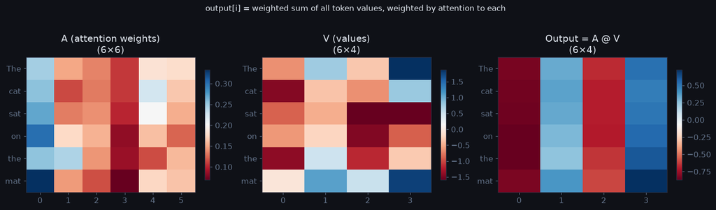

```
Single-head attention output shape: (6, 4)  (seq_len, d_k)

For token 'cat' (row 1):
  Attention weights: [0.255 0.114 0.133 0.108 0.225 0.165]
  → its output is: A[1,:] @ V = [-0.839  0.358 -0.699  0.483]
```

```python
output_h0 = weights_h0 @ V0   # (6, 4)

fig, axes = plt.subplots(1, 3, figsize=(14, 4))
for ax, mat, title in zip(axes,
    [weights_h0, V0, output_h0],
    ["A (attention weights)\n(6×6)", "V (values)\n(6×4)", "Output = A @ V\n(6×4)"]):
    im = ax.imshow(mat, aspect="auto", cmap="RdBu")
    ax.set_yticks(range(SEQ_LEN)); ax.set_yticklabels(TOKENS)
    ax.set_title(title, pad=6)
    plt.colorbar(im, ax=ax, fraction=0.03)
plt.suptitle("output[i] = weighted sum of all token values, weighted by attention to each",
             y=1.02, fontsize=11)
plt.tight_layout(); plt.show()

print("Single-head attention output shape:", output_h0.shape, " (seq_len, d_k)")
print("\nFor token 'cat' (row 1):")
print(f"  Attention weights: {weights_h0[1].round(3)}")
print(f"  → its output is: A[1,:] @ V = {output_h0[1].round(3)}")
```

## 9 · Full Single-Head Attention — All Steps Together

$$\text{Attention}(Q, K, V) = \text{softmax}\!\left(\frac{QK^\top}{\sqrt{d_k}}\right) V$$

This is Equation 1 from the paper. Four operations: multiply, scale, softmax, multiply again.

```python
output_single, weights_single = scaled_dot_product_attention(
    Q0[None, :, :],   # add batch dim
    K0[None, :, :],
    V0[None, :, :],
)
output_single  = output_single[0]    # (6, 4)
weights_single = weights_single[0]   # (6, 6)

print("Single-head attention:")
print(f"  Input X shape:       {X.shape}")
print(f"  Q0, K0, V0 shape:   {Q0.shape}")
print(f"  Attention weights:   {weights_single.shape}")
print(f"  Output shape:        {output_single.shape}")
print(f"\nMax attention weight per row (who each token focuses on most):")
for i, tok in enumerate(TOKENS):
    j = weights_single[i].argmax()
    print(f"  '{tok}' focuses most on '{TOKENS[j]}' ({weights_single[i,j]:.3f})")
```

```
Single-head attention:
  Input X shape:       (6, 8)
  Q0, K0, V0 shape:   (6, 4)
  Attention weights:   (6, 6)
  Output shape:        (6, 4)

Max attention weight per row (who each token focuses on most):
  'The' focuses most on 'The' (0.246)
  'cat' focuses most on 'The' (0.255)
  'sat' focuses most on 'The' (0.270)
  'on' focuses most on 'The' (0.300)
  'the' focuses most on 'The' (0.254)
  'mat' focuses most on 'The' (0.333)
```

## 10 · Multi-Head Attention — Parallel Perspectives

**Why one head is not enough:** One attention head can only model one type of relationship at a time. "cat" might need to find its subject relationship AND its co-reference with "the". One head can't do both simultaneously.

**Multi-head attention:** Split $d_{model}$ into $h$ heads, each with $d_k = d_{model}/h$. Run attention *in parallel* in each sub-space. Each head can specialise in a different linguistic or semantic pattern. Concatenate outputs and project back to $d_{model}$.

$$\text{MultiHead}(Q,K,V) = \text{Concat}(\text{head}_1, \ldots, \text{head}_h) \cdot W^O$$ $$\text{where head}_i = \text{Attention}(QW_i^Q,\; KW_i^K,\; VW_i^V)$$

```python
output_mha, weights_mha = mha.forward(X)
# output_mha:  (6, 8)        — same shape as input X
# weights_mha: (2, 6, 6)     — one (6,6) attention map per head

print(f"Multi-head attention output shape: {output_mha.shape}")
print(f"Attention weights shape: {weights_mha.shape}  (n_heads, seq_len, seq_len)")
```

```
Multi-head attention output shape: (6, 8)
Attention weights shape: (2, 6, 6)  (n_heads, seq_len, seq_len)
```

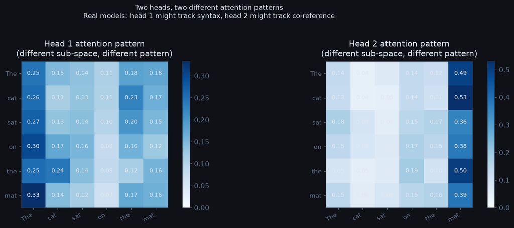

```
Similarity between head patterns:
  Pearson r = -0.0180  (low = they learned different things)
```

```python
fig, axes = plt.subplots(1, 2, figsize=(14, 5))

for h, ax in enumerate(axes):
    im = ax.imshow(weights_mha[h], cmap="Blues", vmin=0, vmax=weights_mha[h].max())
    ax.set_xticks(range(SEQ_LEN))
    ax.set_xticklabels([f"{t}" for t in TOKENS], rotation=30, ha="right", fontsize=10)
    ax.set_yticks(range(SEQ_LEN))
    ax.set_yticklabels(TOKENS, fontsize=10)
    ax.set_title(f"Head {h+1} attention pattern\n(different sub-space, different pattern)", pad=8)
    plt.colorbar(im, ax=ax, fraction=0.04)
    for i in range(SEQ_LEN):
        for j in range(SEQ_LEN):
            ax.text(j, i, f"{weights_mha[h,i,j]:.2f}", ha="center", va="center",
                    fontsize=9, color="white" if weights_mha[h,i,j] > 0.3 else "#e2e8f0")

plt.suptitle(
    "Two heads, two different attention patterns\n"
    "Real models: head 1 might track syntax, head 2 might track co-reference",
    y=1.02, fontsize=11)
plt.tight_layout(); plt.show()

print("Similarity between head patterns:")
flat1, flat2 = weights_mha[0].flatten(), weights_mha[1].flatten()
print(f"  Pearson r = {np.corrcoef(flat1, flat2)[0,1]:.4f}  (low = they learned different things)")
```

## 11 · Add & Normalise (Residual Connection + LayerNorm)

After attention, two operations happen before the FFN:

### Residual Connection

$$X' = X + \text{MultiHeadAttention}(X)$$

**Why:** ensures gradients flow directly back to early layers (solves vanishing gradients). The block learns a *delta* on top of X, not a full transform. Think: "what new information did attention bring, in addition to what X already knew?"

### Layer Normalisation

$$X'' = \text{LayerNorm}(X') = \frac{X' - \mu}{\sigma + \epsilon}$$

Normalises each token's embedding to zero mean, unit variance. Keeps activations in a stable range, speeds up training.

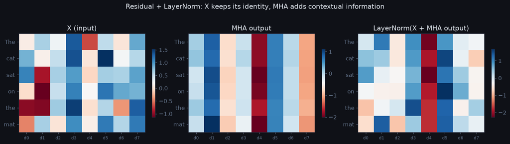

```
Mean per token BEFORE LayerNorm: [ 0.125  0.413  0.171  0.141 -0.045  0.192]
Mean per token AFTER  LayerNorm: [-0.  0.  0.  0.  0. -0.]  ← near 0
Std  per token AFTER  LayerNorm: [1. 1. 1. 1. 1. 1.]   ← near 1
```

```python
X_after_attn = layer_norm(X + output_mha)

fig, axes = plt.subplots(1, 3, figsize=(14, 3.8))
for ax, mat, title in zip(axes,
    [X, output_mha, X_after_attn],
    ["X (input)", "MHA output", "LayerNorm(X + MHA output)"]):
    im = ax.imshow(mat, aspect="auto", cmap="RdBu")
    ax.set_yticks(range(SEQ_LEN)); ax.set_yticklabels(TOKENS)
    ax.set_xticks(range(D_MODEL)); ax.set_xticklabels([f"d{j}" for j in range(D_MODEL)], fontsize=8)
    ax.set_title(title, pad=6)
    plt.colorbar(im, ax=ax, fraction=0.025)
plt.suptitle("Residual + LayerNorm: X keeps its identity, MHA adds contextual information",
             y=1.02)
plt.tight_layout(); plt.show()

print(f"Mean per token BEFORE LayerNorm: {(X + output_mha).mean(axis=1).round(3)}")
print(f"Mean per token AFTER  LayerNorm: {X_after_attn.mean(axis=1).round(3)}  ← near 0")
print(f"Std  per token AFTER  LayerNorm: {X_after_attn.std(axis=1).round(3)}   ← near 1")
```

## 12 · Feed-Forward Network — Processing Each Token Independently

After attention gathers context, the FFN *processes* each token's updated representation.

$$\text{FFN}(x) = \max(0,\; x W_1 + b_1) \cdot W_2 + b_2$$

- $W_1 \in \mathbb{R}^{d_{model} \times d_{ff}}$, $W_2 \in \mathbb{R}^{d_{ff} \times d_{model}}$
- Typically $d_{ff} = 4 \times d_{model}$ (expand then compress)
- Applied **identically and independently** to each token position
- ReLU non-linearity adds expressive power

**Attention vs FFN — what each does:**

- **Attention:** mixes information *across* tokens (context gathering)
- **FFN:** processes each token's representation *in place* (feature transformation)

Both are needed. The FFN is where most of the model's "knowledge" is stored.

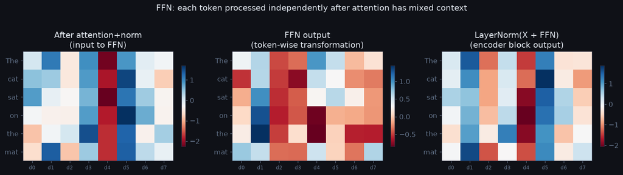

```python
ff = FeedForward(D_MODEL, D_FF, seed=42)
X_after_ff = ff.forward(X_after_attn)
X_final    = layer_norm(X_after_attn + X_after_ff)

fig, axes = plt.subplots(1, 3, figsize=(14, 3.8))
for ax, mat, title in zip(axes,
    [X_after_attn, X_after_ff, X_final],
    ["After attention+norm\n(input to FFN)",
     "FFN output\n(token-wise transformation)",
     "LayerNorm(X + FFN)\n(encoder block output)"]):
    im = ax.imshow(mat, aspect="auto", cmap="RdBu")
    ax.set_yticks(range(SEQ_LEN)); ax.set_yticklabels(TOKENS)
    ax.set_xticks(range(D_MODEL)); ax.set_xticklabels([f"d{j}" for j in range(D_MODEL)], fontsize=8)
    ax.set_title(title, pad=6)
    plt.colorbar(im, ax=ax, fraction=0.025)
plt.suptitle("FFN: each token processed independently after attention has mixed context",
             y=1.02)
plt.tight_layout(); plt.show()
```

## 13 · The Full Encoder Block — Putting It All Together

One encoder block = Multi-Head Attention + Add&Norm + FFN + Add&Norm.

```
X (seq_len, d_model)
│
├──→ Multi-Head Self-Attention ──→ + ──→ LayerNorm ──→ X'
│                                  ↑
│                                  X (residual)
│
├──→ Feed-Forward Network ──────→ + ──→ LayerNorm ──→ output
│                                  ↑
│                                  X' (residual)
```

BERT uses 12 of these stacked. GPT-3 uses 96. Each block refines the representations.

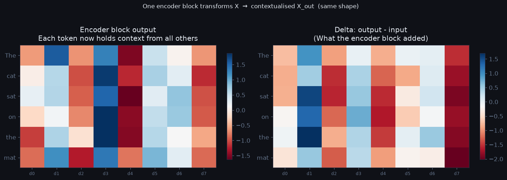

```
Input shape:  (6, 8)
Output shape: (6, 8)  ← identical shape (can stack N blocks)
```

```python
block = EncoderBlock(D_MODEL, N_HEADS, D_FF, seed=42)
X_out, block_weights = block.forward(X)

fig, axes = plt.subplots(1, 2, figsize=(13, 4.5))

ax = axes[0]
im = ax.imshow(X_out, aspect="auto", cmap="RdBu")
ax.set_yticks(range(SEQ_LEN)); ax.set_yticklabels(TOKENS)
ax.set_xticks(range(D_MODEL)); ax.set_xticklabels([f"d{j}" for j in range(D_MODEL)], fontsize=8)
ax.set_title("Encoder block output\nEach token now holds context from all others", pad=8)
plt.colorbar(im, ax=ax, fraction=0.025)

ax = axes[1]
diff = X_out - X
im = ax.imshow(diff, aspect="auto", cmap="RdBu")
ax.set_yticks(range(SEQ_LEN)); ax.set_yticklabels(TOKENS)
ax.set_xticks(range(D_MODEL)); ax.set_xticklabels([f"d{j}" for j in range(D_MODEL)], fontsize=8)
ax.set_title("Delta: output - input\n(What the encoder block added)", pad=8)
plt.colorbar(im, ax=ax, fraction=0.025)

plt.suptitle("One encoder block transforms X  →  contextualised X_out  (same shape)",
             y=1.02, fontsize=11)
plt.tight_layout(); plt.show()

print(f"Input shape:  {X.shape}")
print(f"Output shape: {X_out.shape}  ← identical shape (can stack N blocks)")
```

## 14 · Where This Lives in Modern AI

Every major LLM, vision model, and speech model is built from these same blocks.

| Model | Input tokens | Key use of attention |
| --- | --- | --- |
| **BERT** | Words | Bidirectional: every word attends to every other |
| **GPT / LLaMA** | Words | Causal (masked): token i only attends to 0…i |
| **ViT** | Image patches | Patches attend to patches → vision understanding |
| **Whisper** | Audio spectrogram | Cross-attention: decoder attends to audio encoder |
| **DALL-E / Stable Diffusion** | Pixels + text | Cross-attention: image attends to text tokens |
| **AlphaFold 2** | Amino acids | Self-attention over protein sequence + structure |

### The two variants of attention

**Self-attention** (what we built): Q, K, V all come from the same sequence. Used in encoder (BERT) and decoder (GPT, LLaMA).

**Cross-attention**: Q from sequence A, K/V from sequence B. Used in encoder-decoder models (translation, Whisper, T5). Lets the decoder "look at" the encoder's output while generating.

```
Causal mask (True = blocked):
[[0 1 1 1 1 1]
 [0 0 1 1 1 1]
 [0 0 0 1 1 1]
 [0 0 0 0 1 1]
 [0 0 0 0 0 1]
 [0 0 0 0 0 0]]

This ensures autoregressive generation: predict token t using only tokens 0..t-1
```

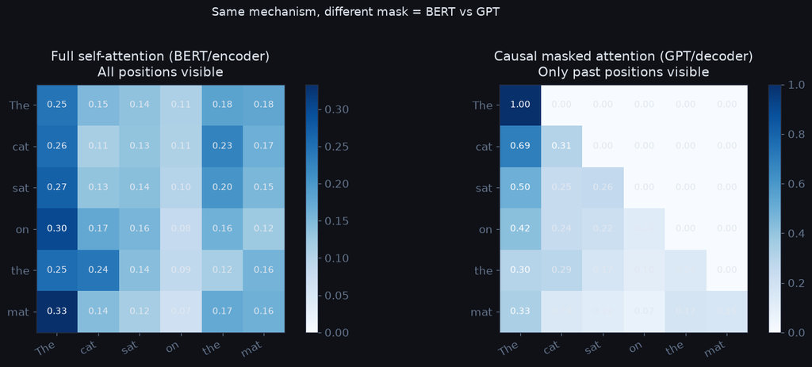

```python
# DEMO: Causal (masked) attention — how GPT/LLaMA work
# Tokens can only attend to PAST tokens, not future ones.
# Enforced by a mask that sets future positions to -inf before softmax.

# Upper-triangular mask: position i cannot attend to position j > i
mask = np.triu(np.ones((SEQ_LEN, SEQ_LEN), dtype=bool), k=1)
print("Causal mask (True = blocked):")
print(mask.astype(int))
print("\nThis ensures autoregressive generation: predict token t using only tokens 0..t-1")

_, weights_causal = scaled_dot_product_attention(
    Q0[None], K0[None], V0[None], mask=mask[None]
)
weights_causal = weights_causal[0]

fig, axes = plt.subplots(1, 2, figsize=(13, 5))
for ax, w, title in zip(axes,
    [weights_single, weights_causal],
    ["Full self-attention (BERT/encoder)\nAll positions visible",
     "Causal masked attention (GPT/decoder)\nOnly past positions visible"]):
    im = ax.imshow(w, cmap="Blues", vmin=0)
    ax.set_xticks(range(SEQ_LEN)); ax.set_xticklabels(TOKENS, rotation=30, ha="right")
    ax.set_yticks(range(SEQ_LEN)); ax.set_yticklabels(TOKENS)
    ax.set_title(title, pad=8)
    plt.colorbar(im, ax=ax, fraction=0.04)
    for i in range(SEQ_LEN):
        for j in range(SEQ_LEN):
            val = w[i, j]
            ax.text(j, i, f"{val:.2f}", ha="center", va="center",
                    fontsize=9, color="white" if val > 0.3 else "#e2e8f0")

plt.suptitle("Same mechanism, different mask = BERT vs GPT", y=1.02, fontsize=12)
plt.tight_layout(); plt.show()
```

## 15 · Use Cases for Your Projects

### When does attention run under the hood?

| Your action | What attention computes |
| --- | --- |
| `client.chat()` → LLM response | Causal self-attention over your prompt tokens |
| RAG retrieval → embed document | Encoder self-attention builds the embedding |
| `embed(text)` → vector | The [CLS] token's output after full self-attention |
| Whisper transcription | Cross-attention: decoder attends to audio encoder |
| Image classification (ViT) | Self-attention over 16×16 pixel patches |

### When you might implement attention yourself

| Scenario | What to build |
| --- | --- |
| Custom sequence model | `EncoderBlock` from `attention.py` |
| Recommendation (users × items) | Cross-attention: user query attends to item keys |
| Multi-modal fusion | Cross-attention between two modalities |
| Time-series anomaly | Self-attention finds which time steps correlate |
| Structured data (tabular) | Attention across feature columns |

### The one-line mental model

> **Attention lets every element of a sequence ask a question (Q), and every other element answer (K) and contribute information (V).**

> Trained attention = the model has learned *which* questions to ask and *what information* each position should contribute.

## 16 · What the Transformer Encoder Does — Full Summary

| Step | Operation | Input shape | Output shape | Why |
| --- | --- | --- | --- | --- |
| 1 | Embed tokens | (seq,) int | (seq, d_model) | Tokens → continuous vectors |
| 2 | Add PE | (seq, d_model) | (seq, d_model) | Inject position information |
| 3 | Project Q, K, V | (seq, d_model) | 3 × (seq, d_model) | Learn what to ask/answer/give |
| 4 | Attention scores | (seq, d_k) × (d_k, seq) | (seq, seq) | How much each token attends to each |
| 5 | Scale ÷√d_k | (seq, seq) | (seq, seq) | Prevent softmax saturation |
| 6 | Softmax | (seq, seq) | (seq, seq) | Normalise to probability over positions |
| 7 | Weighted sum V | (seq, seq) × (seq, d_k) | (seq, d_k) | Gather context |
| 8 | Concat + W_O | h × (seq, d_k) | (seq, d_model) | Merge all heads |
| 9 | Residual + LN | (seq, d_model) | (seq, d_model) | Gradient flow + stability |
| 10 | FFN | (seq, d_model) | (seq, d_model) | Per-token feature transformation |
| 11 | Residual + LN | (seq, d_model) | (seq, d_model) | Gradient flow + stability |

**Stack N of these = BERT (N=12), GPT-3 (N=96), LLaMA-70B (N=80)**

```python
# Final verification: run the full encoder block on our sentence
print("FULL ENCODER BLOCK — end to end")
print("=" * 50)
print(f"Input:  'The cat sat on the mat'")
print(f"        {SEQ_LEN} tokens x {D_MODEL} dims = {SEQ_LEN*D_MODEL} numbers")
print()

block2 = EncoderBlock(D_MODEL, N_HEADS, D_FF, seed=99)
out, w  = block2.forward(X)

print(f"Output: same shape {out.shape}")
print(f"        Each token now holds context from all 6 tokens")
print()
print("Dominant attention per token (who each word focused on most):")
for i, tok in enumerate(TOKENS):
    j = w.mean(axis=0)[i].argmax()   # average across heads
    print(f"  '{tok:<5}' → '{TOKENS[j]}'  ({w.mean(axis=0)[i,j]:.3f})")
print()
print("These patterns are random (untrained weights).")
print("After training on text: 'cat' would attend to 'sat' (subject→verb)")
print("'mat' would attend to 'the' immediately before it, etc.")
```

```
FULL ENCODER BLOCK — end to end
==================================================
Input:  'The cat sat on the mat'
        6 tokens x 8 dims = 48 numbers

Output: same shape (6, 8)
        Each token now holds context from all 6 tokens

Dominant attention per token (who each word focused on most):
  'The  ' → 'sat'  (0.381)
  'cat  ' → 'sat'  (0.289)
  'sat  ' → 'cat'  (0.215)
  'on   ' → 'sat'  (0.305)
  'the  ' → 'sat'  (0.459)
  'mat  ' → 'sat'  (0.448)

These patterns are random (untrained weights).
After training on text: 'cat' would attend to 'sat' (subject→verb)
'mat' would attend to 'the' immediately before it, etc.
```